# Variable Selection

Duong Trinh

2022-08-19

$\newcommand{\mathbbm}[1]{\mathbb{#1}}$

# 1 Data Generating Process

```r
# Support Packages
library(tidyverse)
```

```r
library(purrr)
library(ggplot2)
library(gridExtra)
# Data Generating Process
# Note: library(pracma) # for a (non-symmetric) Toeplitz matrix
GenRegr <- function(n,p,options) {
  # Generate predictors x
  if (options.corr == 0) {# Uncorrelated predictors
    x = matrix(rnorm(n*p),n,p)
  }
  else if (options.corr == 1) {# Spatially ncorrelated predictors
    C = toeplitz(options.rho^(0:(p-1)))
    x = matrix(rnorm(n*p),n,p)%*%chol(C)
  }
  else {
    print('Wrong choice of options.corr')
  }

  x <- data.matrix(sapply(data.frame(x), function(x) {(x-mean(x))/sd(x)})) # Standardize x

  # Generate coefficients
  beta <- rep(0,p)
  beta[1:6] <- c(1.5,-1.5,2,-2,2.5,-2.5)

  if (options.corr == 0) {
    signal_y <- sum(beta^2)
  }
  else if (options.corr == 1) {
    signal_y <- sum((chol(C)%*%beta)^2)
  }

  c <- signal_y*((1-options.R2)/options.R2) # mean(sigmasq) is c to obtain desirable options.R2 (or SNR)

  # Generate epsilon
  if (options.epsilon == 0) { # iid error
    sigmasq <- c
  }
  else if (options.epsilon == 1) {
    temp = (x%*%beta)
    sigmasq = c*temp/mean(temp)
  }

  epsilon = sqrt(sigmasq) * rnorm(n)

  # Generate y
  y = x%*%beta + epsilon

  return(list(y = y, x = x, beta = beta, sigmasq = sigmasq))
}
```

## 1.1 DGP 1 - Homoskedasticity, Uncorrelated predictors, Rsquared = 0.4 (n = 100, p = 50)

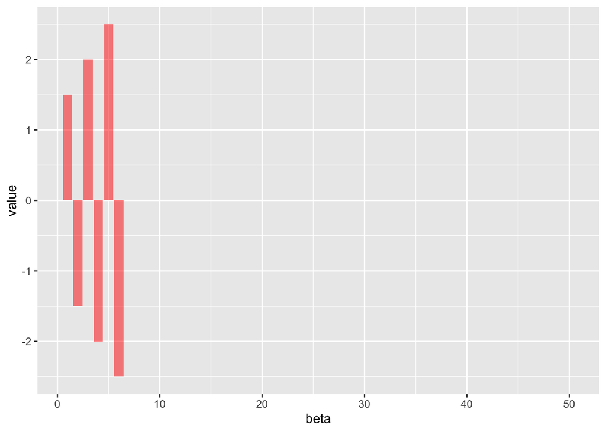

```r
# Data Generating Process ====
set.seed(2907)
n = 100
p = 50
options.corr = 0
options.R2 = 0.4
options.epsilon = 0
options.rho = NA

df <- GenRegr(n, p, options)

y <- df$y
X <- df$x
beta_true <-  df$beta
sigmasq_true <- df$sigmasq

df_beta_true <- data.frame(beta = 1:length(beta_true), value = beta_true)

ggplot(df_beta_true, aes(x = beta, y = value)) +
  geom_bar(fill = "red", stat = "identity", position = "identity", alpha = 0.5)
```

# 2 Methods

```r
library(Rcpp)
library(RcppArmadillo)
sourceCpp("/Users/duongtrinh/Dropbox/FIELDS/Data Science/R_Data Science/R Practice/CPPDuong/BayesRegrSP.cpp")

sourceCpp("/Users/duongtrinh/Dropbox/FIELDS/Data Science/R_Data Science/R Practice/CPPDuong/BayesRegr.cpp")
```

# 3 Simulations

## 3.1 Nsim = 1

```r
resRcpp_st <- BayesRegrSP(y,X,nsave=2000,nburn=100,prior="student-t")
resRcpp_nosp <- BayesRegr(y,X,nsave=2000,nburn=100)
```

## 3.2 Nsim = 10

### 3.2.1 Nsim = 10 (Parallel computation)

```r
doOne <- function(n, p, names = FALSE)
{
  df <- GenRegr(n, p, options)
  y <- df$y
  X <- df$x
  beta_true <-  df$beta
  sigmasq_true <- df$sigmasq

  nsave <- 2000
  nburn <-  100

  beta_est <- array(rep(NA,p*nsave*2),dim = c(p,nsave,2))

  resRcpp_nosp <- BayesRegr(y,X,nsave=nsave,nburn=nburn)
  resRcpp_st <- BayesRegrSP(y,X,nsave=nsave,nburn=nburn,prior="student-t")

  beta_est[,,1] <- resRcpp_nosp$betadraws
  beta_est[,,2] <- resRcpp_st$betadraws

  return(beta_est)
}
```

```r
n <- 100
p <- 50
nsave <- 2000
Nsim <- 10
beta_true <- rep(0,p)
beta_true[1:6] <- c(1.5,-1.5,2,-2,2.5,-2.5)


library(parallel)
library(tictoc)
tic()
res1 <- lapply(1:Nsim, function(sim) doOne(n,p))
toc()
```

```
## 5.806 sec elapsed
```

```r
tic()
res2 <- mclapply(1:Nsim, function(sim) doOne(n,p),
                 mc.set.seed = TRUE,
                 mc.cores = getOption("mc.cores", 8L))
toc()
```

```
## 1.527 sec elapsed
```

```r
res3 <- array(unlist(res2),
              dim = c(p,nsave,2,Nsim),
              dimnames = list(beta = map_chr(1:p,~paste0("b",.x)),
                              iter = map_chr(1:nsave,~paste0("iter",.x)),
                              method = c("NoShrinkage", "CTS-Studt"),
                              sim = map_chr(1:Nsim,~paste0("sim",.x))))

library(reshape2)
res4 <- melt(res3, value.name = "value")
```

# 4 Approach 1 - 2-means (2-M) variable selection

## 4.1 Reference

- [Variable selection using shrinkage priors](https://www.sciencedirect.com/science/article/pii/S0167947316302353)

## 4.2 Idea

Doing variable selection using shrinkage priors by post-processing posterior samples of the regression coefficients.

### 4.2.2 Sequential 2-means (S2M) variable selection

**Algorithm**

Define $S_T$ to be the indices of non-zero signals in $\beta_T$ and $S_E$ to be the indices of the selected covariates.

Consider two types of errors:

- $\mid S_T \cap S_E^C\mid$: masking error (false negative)
- $\mid S_E \cap S_T^C \mid$: swamping error (false positive)

Let $b > 0$ be a tuning parameter, then *Sequential 2-means (S_2M)* is defined as follows: On the $i^{th}$ MCMC sample of $\beta$:

1. Perform a 2-means algorithm on $\mid \beta_j \mid, j = 1,2,\ldots,p$. Denote the cluster means with smaller values by $m$ and the one with larger values by $M$ ($m < M$). Initialize a set $D$ with all the indices from the cluster with the smaller mean $m$. While the difference $M - m$ is greater than $b$:
1. update $D$ to be all the indices from the cluster with the smaller mean $m$;
2. perform a 2-means on $\mid\beta_j\mid, j\in D$;
3. update $m$ and $M$ to be two cluster means ($m \leq M$) obtained from (b).
2. The set $D$ is considered to contain coefficients of noise covariates. So the estimated number of signals $h_i$ is $p - \mid D\mid$

## 4.3 Implementation:

```r
O2M <- function(Beta)
{

  N=dim(Beta)[1]
  p=dim(Beta)[2]

  KK = rep(NA,N)

  for (i in 1:N) {
      fit = kmeans(abs(as.numeric(Beta[i,])),2)
      KK[i] = min(fit$size)
  }

  # Determine the number of non-zeros signals
  H = as.numeric(names(sort(table(KK), decreasing = TRUE))[1])

  # Calculate median
  beta_median = rep(NA, p)
  for(j in 1:p)
  {
    beta_median[j] = median(Beta[,j])
  }

  # Find the H largest value
  sorted = sort(abs(beta_median), decreasing = TRUE, index.return = TRUE)
  sortedVal = sorted$x
  sortedInx = sorted$ix

  topH = sortedInx[1:H]

  beta_res = rep(0,p)
  beta_res[topH] = sortedVal[topH]

  return(list(N = N,
              p = p,
              H = H,
              signals = beta_res
    ))
}
```

```r
###################
#S2M main function#
###################


#This function creates a sequence $\{b_i\}$ of $l$ values of the tuning parameter and implements Sequential-2-Means on the posterior samples to obtain variable selection results corresponding to each value in the sequence $\{b_i\}$. }
#\arguments{
# \item{Beta}{
#   it is an $N$ by $p$ matrix consisting of $N$ posterior samples of $p$ variables
# }
# \item{lower}{
#   the lower bound of the chosen values of the tuning parameter
# }
# \item{upper}{
#   the upper bound of the chosen values of the tuning parameter
# }
# \item{l}{
#   the number of chosen values of the tuning parameter
# }


# \value{
#   \item{N }{the posterior sample size}
#   \item{p }{the total number of variables}
#
#   \item{H.b.i }{the estimated number of signals corresponding to each $b_i$}
#   \item{b.i }{the values of the tuning parameter}
#
#   \item{abs.post.median }{medians of the absolute values of the posterior samples of each variable}
#
S2M = function(Beta,lower,upper,l)
{

  N=dim(Beta)[1]
  p=dim(Beta)[2]

  b.i=seq(lower,upper,length=l)
  H.b.i=NULL
  for(r in 1:l)
  {
    KK=NULL
    for (i in 1:N)
    {
      fit=kmeans(abs(as.numeric(Beta[i,])),2)
      cen1=min(fit$centers)
      cen2=max(fit$centers)
      temp1=Beta[i,]


      fit1=fit

      while(cen2-cen1>b.i[r])
      {
        fit1=fit
        temp=which.min(fit$centers)
        temp1=temp1[which(fit$cluster==temp)]
        if(length(temp1)<=2){break;}
        fit=kmeans(abs(as.numeric(temp1)),2)
        cen2=max(fit$centers)
        cen1=min(fit$centers)
      }
      temp=which.min(fit1$centers)
      KK[i]=p-length(which(fit1$cluster==temp))
    }
    H.b.i[r]=as.numeric(names(sort(-table(KK)))[1])
  }
  abs.post.median=NULL
  for(i in 1:p)
  {
    abs.post.median[i]=median(abs(Beta[,i]))
  }
  return(list(N=N,
              p=p,
              H.b.i=H.b.i,
              b.i=b.i,
              abs.post.median=abs.post.median
    ))
}



############################
#make a H_b_i v.s. b_i plot#
############################
#This function is to make the $H_{b_{i}}$-v.s.-$b_i$ plot. The estimated number of signals, or equivalently, the optimal value of the tuning parameter can be decided by looking at this plot.
# \arguments{
#   \item{S2M}{a list obtained from the function \code{S2M}.}
# }
Hbi.vs.bi=function(S2M)
{
  plot(S2M$b.i,S2M$H.b.i)
}




###############################
#variable selection results   #
#given a particular value of H#
###############################
#This function is to print out the variable selection results given the estimated number of signals.}
# \arguments{
#   \item{S2M}{a list obtained from the function \code{S2M}.}
#   \item{H}{the estimated number of signals}
# }
# \value{
#   \item{var.selected}{The indices of selected variables}
#  }

S2M.vs=function(S2M,H)
{
  p=S2M$p
  abs.post.median=S2M$abs.post.median
  var.selected=order(abs.post.median)[p:(p-H+1)]
  return(var.selected)
}
```

```r
resRcpp <- resRcpp_nosp
beta_post <- data.frame(t(resRcpp$betadraws))
resO2M <- O2M(beta_post)
resO2M
```

```
## $N
## [1] 2000
##
## $p
## [1] 50
##
## $H
## [1] 14
##
## $signals
##  [1] 0.000000000 3.144709175 2.772704742 2.207037653 1.674709135 1.660998994
##  [7] 0.000000000 0.000000000 1.245881218 0.000000000 0.000000000 0.000000000
## [13] 1.105011709 0.000000000 0.000000000 0.920365255 0.000000000 0.000000000
## [19] 0.000000000 0.821781838 0.804916861 0.000000000 0.000000000 0.000000000
## [25] 0.000000000 0.000000000 0.000000000 0.000000000 0.000000000 0.000000000
## [31] 0.647129640 0.000000000 0.000000000 0.000000000 0.000000000 0.000000000
## [37] 0.447847625 0.000000000 0.416417446 0.000000000 0.000000000 0.000000000
## [43] 0.000000000 0.000000000 0.000000000 0.000000000 0.007763571 0.000000000
## [49] 0.000000000 0.000000000
```

```r
# resS2M <- S2M(beta_post,0,1,100)
# Hbi.vs.bi(resS2M)
# S2M.vs(resS2M,6)
```

```r
resRcpp <- resRcpp_st
beta_post <- data.frame(t(resRcpp$betadraws))
resO2M <- O2M(beta_post)
resO2M
```

```
## $N
## [1] 2000
##
## $p
## [1] 50
##
## $H
## [1] 3
##
## $signals
##  [1] 0.000000000 0.000000000 0.486686663 0.478367156 0.005113969 0.000000000
##  [7] 0.000000000 0.000000000 0.000000000 0.000000000 0.000000000 0.000000000
## [13] 0.000000000 0.000000000 0.000000000 0.000000000 0.000000000 0.000000000
## [19] 0.000000000 0.000000000 0.000000000 0.000000000 0.000000000 0.000000000
## [25] 0.000000000 0.000000000 0.000000000 0.000000000 0.000000000 0.000000000
## [31] 0.000000000 0.000000000 0.000000000 0.000000000 0.000000000 0.000000000
## [37] 0.000000000 0.000000000 0.000000000 0.000000000 0.000000000 0.000000000
## [43] 0.000000000 0.000000000 0.000000000 0.000000000 0.000000000 0.000000000
## [49] 0.000000000 0.000000000
```

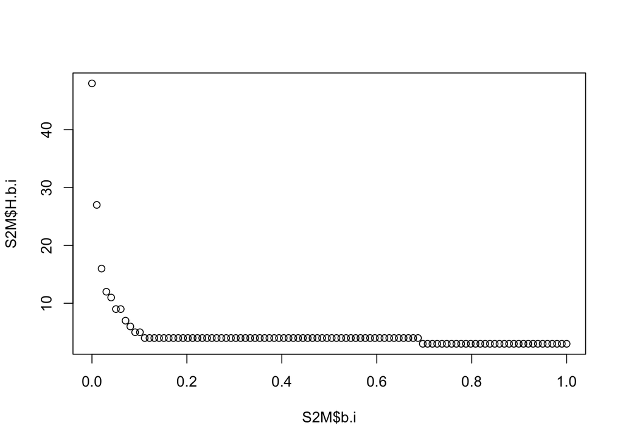

```r
resS2M <- S2M(beta_post,0,1,100)
Hbi.vs.bi(resS2M)
```

```r
S2M.vs(resS2M,6)
```

```
## [1]  5  3  4  6 24 40
```

# 5 Approach 2 - Using AUPRC

## 5.1 Reference:

- [Comparing methods for statistical inference with model uncertainty](https://www.pnas.org/doi/pdf/10.1073/pnas.2120737119)

## 5.2 Ideas:

To compare the performance of the techniques for identifying the appropriate variables, we calculated the area under the precision recall curve (AUPRC) for each of the techniques. This gives an overall assessment of model selection quality and does not require a threshold to be chosen for the posterior inclusion probability of a covariate.

- For the horseshoe, the AUPRC was obtained by varying the credible set levels leading to different number of variables being selected by the method.
- For penalized likelihood based approaches, the AUPRC was obtained b varying the cross-validation parameterλfrom close to 0 (no penalization) to $\lambda_{max}$, defined as the smallest value of $\lambda$ for which none of the variables is included in the model.
- We report Inference with (1 – AUPRC) as our metric, and a lower value is better.

## 5.3 Implementation:

### 5.3.1 Nsim = 1

**No Shrinkage**

```r
# resRcpp <- resRcpp_st
resRcpp <- resRcpp_nosp

names_beta <- map_chr(1:nrow(resRcpp$betadraws),~paste0(.x))

df_beta <- data.frame(t(resRcpp$betadraws)) %>%
  `names<-`(.,names_beta) %>%
  mutate(nsave = 1:ncol(resRcpp$betadraws)) %>%
  gather(., beta, value, -c("nsave")) %>%
  mutate(beta = factor(beta, level = names_beta))
```

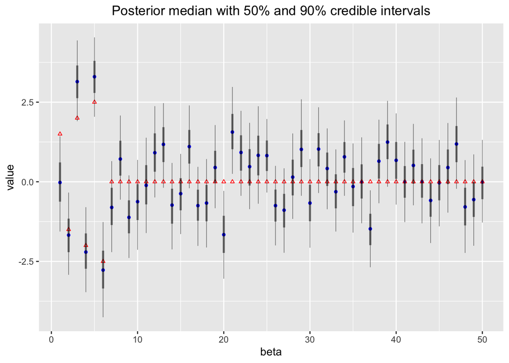

```r
df_beta2 <- df_beta %>% group_by(beta) %>%
  summarise(ub = quantile(value,0.95),
            lb = quantile(value,0.05),
            UB = quantile(value,0.75),
            LB = quantile(value,0.25),
            m = median(value)) %>%
  mutate(true = beta_true, beta = 1:p)

ggplot(df_beta2, aes(x = beta, y = m)) +
  geom_point(size = 1, col = "blue") +
  geom_point(aes(x = beta, y = true), size = 1, col = "red", shape = 2) +
  geom_linerange(aes(ymin = LB, ymax = UB), size=1, alpha = 0.5) +
  geom_linerange(aes(ymin = lb, ymax = ub), size=0.3, alpha = 0.5) +
  xlab("beta") +
  ylab("value") +
  ggtitle("Posterior median with 50% and 90% credible intervals") +
  # coord_flip() +
  theme(plot.background = element_rect(fill = "transparent", colour = NA)) +
  theme(plot.title = element_text(hjust = 0.5))
```

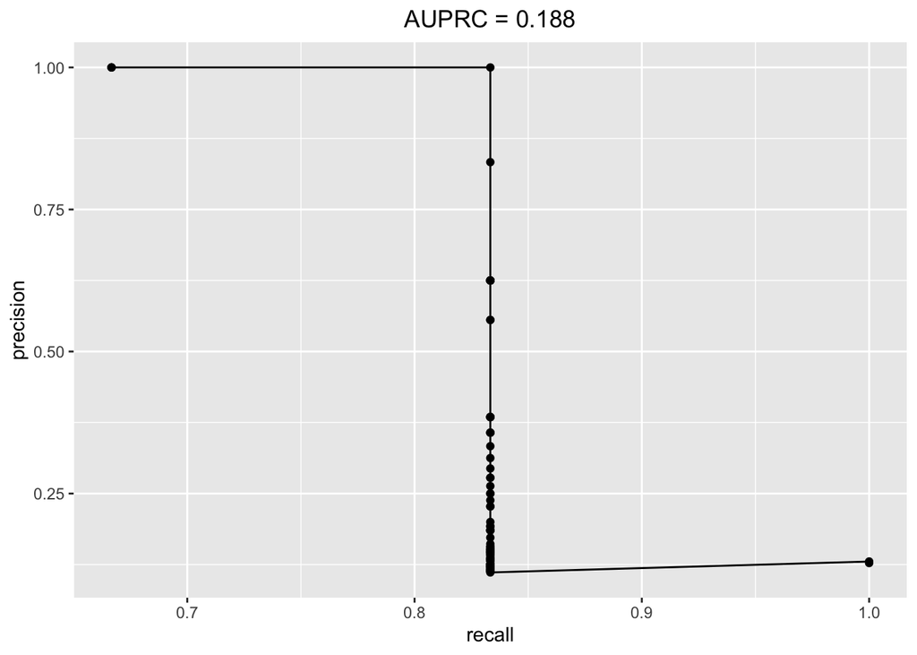

```r
PRpair <- function(th) {
  df_beta %>% group_by(beta) %>%
    summarise(ub = quantile(value, 0.5 + th/2),
              lb = quantile(value, 0.5 - th/2),
              m = as.numeric(lb > 0 | ub < 0)) %>%
    select(m) %>%
    mutate(d = as.numeric(beta_true != 0)) %>%
    summarise(TP = sum(m == 1 & d == 1),
            FP = sum(m == 1 & d == 0),
            FN = sum(m == 0 & d == 1),
            precision = case_when(TP + FP == 0 ~ 0,
                                  TP + FP != 0 ~ TP/(TP + FP)),
            recall = TP/(TP + FN)) %>%
    select(precision, recall, TP, FP, FN)
}

grid.th <- seq(0.99,0.01,-0.01)

library(purrr)
PRdf <- do.call('rbind', map(grid.th, PRpair)) %>% arrange(recall)

auprc <- sum(diff(PRdf$recall)*PRdf$precision[-1])

ggplot(PRdf, aes(x = recall, y = precision)) +
  geom_point() +
  geom_line() +
  ggtitle(paste0("AUPRC = ", round(auprc,3))) +
  theme(plot.title = element_text(hjust = 0.5))
```

**CTS-Studt prior**

```r
resRcpp <- resRcpp_st
# resRcpp <- resRcpp_nosp

names_beta <- map_chr(1:nrow(resRcpp$betadraws),~paste0(.x))

df_beta <- data.frame(t(resRcpp$betadraws)) %>%
  `names<-`(.,names_beta) %>%
  mutate(nsave = 1:ncol(resRcpp$betadraws)) %>%
  gather(., beta, value, -c("nsave")) %>%
  mutate(beta = factor(beta, level = names_beta))
```

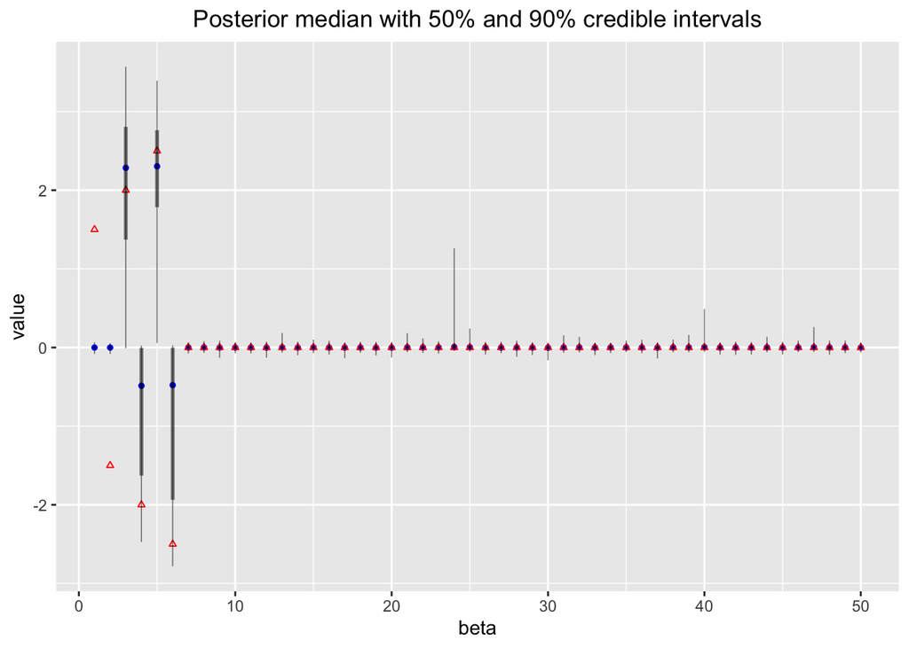

```r
df_beta2 <- df_beta %>% group_by(beta) %>%
  summarise(ub = quantile(value,0.95),
            lb = quantile(value,0.05),
            UB = quantile(value,0.75),
            LB = quantile(value,0.25),
            m = median(value)) %>%
  mutate(true = beta_true, beta = 1:p)

ggplot(df_beta2, aes(x = beta, y = m)) +
  geom_point(size = 1, col = "blue") +
  geom_point(aes(x = beta, y = true), size = 1, col = "red", shape = 2) +
  geom_linerange(aes(ymin = LB, ymax = UB), size=1, alpha = 0.5) +
  geom_linerange(aes(ymin = lb, ymax = ub), size=0.3, alpha = 0.5) +
  xlab("beta") +
  ylab("value") +
  ggtitle("Posterior median with 50% and 90% credible intervals") +
  # coord_flip() +
  theme(plot.background = element_rect(fill = "transparent", colour = NA)) +
  theme(plot.title = element_text(hjust = 0.5))
```

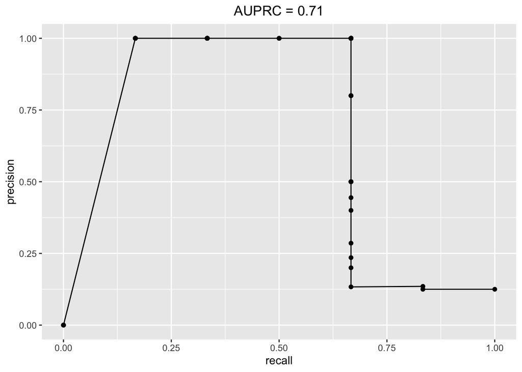

```r
PRpair <- function(th) {
  df_beta %>% group_by(beta) %>%
    summarise(ub = quantile(value, 0.5 + th/2),
              lb = quantile(value, 0.5 - th/2),
              m = as.numeric(lb > 0 | ub < 0)) %>%
    select(m) %>%
    mutate(d = as.numeric(beta_true != 0)) %>%
    summarise(TP = sum(m == 1 & d == 1),
            FP = sum(m == 1 & d == 0),
            FN = sum(m == 0 & d == 1),
            precision = case_when(TP + FP == 0 ~ 0,
                                  TP + FP != 0 ~ TP/(TP + FP)),
            recall = TP/(TP + FN)) %>%
    select(precision, recall, TP, FP, FN)
}

grid.th <- seq(0.99,0.01,-0.01)

library(purrr)
PRdf <- do.call('rbind', map(grid.th, PRpair)) %>% arrange(recall)

auprc <- sum(diff(PRdf$recall)*PRdf$precision[-1])

ggplot(PRdf, aes(x = recall, y = precision)) +
  geom_point() +
  geom_line() +
  ggtitle(paste0("AUPRC = ", round(auprc,3))) +
  theme(plot.title = element_text(hjust = 0.5))
```

### 5.3.2 Nsim = 10

```r
names_method <- c("NoShrinkage", "CTS-Studt")
names_sim <- map_chr(1:Nsim,~paste0("sim",.x))
mat_auprc <- matrix(NA, 2, Nsim)
mat_recall <- matrix(NA, 2, Nsim)
mat_precision <- matrix(NA, 2, Nsim)
mat_TP <- matrix(NA, 2, Nsim)
mat_FP <- matrix(NA, 2, Nsim)
mat_FN <- matrix(NA, 2, Nsim)

for (i in 1:2) {
for (j in 1:Nsim) {

resdf <- res4 %>% filter(sim == names_sim[j], method == names_method[i]) %>%
  select(beta, value)

PRpair <- function(th) {
  resdf %>% group_by(beta) %>%
    summarise(ub = quantile(value, 0.5 + th/2),
              lb = quantile(value, 0.5 - th/2),
              m = as.numeric(lb > 0 | ub < 0)) %>%
    select(m) %>%
    mutate(d = as.numeric(beta_true != 0)) %>%
    summarise(TP = sum(m == 1 & d == 1),
            FP = sum(m == 1 & d == 0),
            FN = sum(m == 0 & d == 1),
            precision = case_when(TP + FP == 0 ~ 0,
                                  TP + FP != 0 ~ TP/(TP + FP)),
            recall = TP/(TP + FN)) %>%
    select(precision, recall, TP, FP, FN)
}

grid.th <- seq(0.99,0.01,-0.01)

library(purrr)
PRdf <- do.call('rbind', map(grid.th, PRpair)) %>% arrange(recall)

# ggplot(PRdf, aes(x = recall, y = precision)) +
#   geom_point() +
#   geom_line()

auprc <- sum(diff(PRdf$recall)*PRdf$precision[-1])
mat_auprc[i, j] <- auprc
mat_recall[i, j] <- mean(PRdf$recall)
mat_precision[i, j] <- mean(PRdf$precision)
mat_TP[i, j] <- mean(PRdf$TP)
mat_FP[i, j] <- mean(PRdf$FP)
mat_FN[i, j] <- mean(PRdf$FN)
}
}

meanAUPRC <- rowMeans(mat_auprc)
meanRECALL <- rowMeans(mat_recall)
meanPRECISION <- rowMeans(mat_precision)
meanTP <- rowMeans(mat_TP)
meanFP <- rowMeans(mat_FP)
meanFN <- rowMeans(mat_FN)

knitr::kable(data.frame(names_method, meanTP, meanFP, meanFN, meanPRECISION, meanRECALL, meanAUPRC))
```

| names_method | meanTP | meanFP | meanFN | meanPRECISION | meanRECALL | meanAUPRC |
| --- | --- | --- | --- | --- | --- | --- |
| NoShrinkage | 5.487879 | 22.896970 | 0.5121212 | 0.2680552 | 0.9146465 | 0.2546561 |
| CTS-Studt | 2.222222 | 1.867677 | 3.7777778 | 0.7768944 | 0.3703704 | 0.8075442 |

# 6 Approach 3 - Using reference models in variable selection

## 6.1 Reference:

- Decoupling Shrinkage and Selection
- [Projective inference in high-dimensional problems: Prediction and feature selection](https://projecteuclid.org/journals/electronic-journal-of-statistics/volume-14/issue-1/Projective-inference-in-high-dimensional-problems--Prediction-and-feature/10.1214/20-EJS1711.full)
- [Using reference models in variable selection](https://link.springer.com/article/10.1007/s00180-022-01231-6)

## 6.2 Ideas

**Rich model vs Feature selection**

- If we care about the predictive performance
  - Include all available prior information
  - Integrate over all uncertainties
  - No need for feature selection
- Variable selection can be useful if
  - need to reduce measurement or computation cost
  - improve explainability
- Two options for variable selection
  - Find a minimal subset of feature that yield a good predictive model
  - Identify all features that have predictive information (complete variable selection)

**Why shrinkage priors alone do not solve the variable selection problem**

- A common strategy:
  - Fit model with a shrinkage prior
  - Select variables based on marginal posteriors of the regression coefficients

**Issues** + Marginal posteriors are difficult with correlated features + How to do posterior inference correctly

## 6.3 Two stage approach

- Construct a best predictive model we can -> reference model
- Variable selection and post-selection inference -> projection